# coursera machine learning

qiuchang

2016年8月13日

# Executive Summary

Human Activity Recognition - HAR - has emerged as a key research area in the last years and is gaining increasing attention by the pervasive computing research community.

Using devices such as Jawbone Up, Nike FuelBand, and Fitbit it is now possible to collect a large amount of data about personal activity relatively inexpensively. These type of devices are part of the quantified self movement – a group of enthusiasts who take measurements about themselves regularly to improve their health, to find patterns in their behavior, or because they are tech geeks. One thing that people regularly do is quantify how much of a particular activity they do, but they rarely quantify how well they do it.

In this project, my goal will be to use data from accelerometers on the belt, forearm, arm, and dumbell of 6 participants.

Loading and Preprocessing the Data Setting up working directory is the first step.

```r
{setwd("D:\\coursea\\gitrepos\\machinelearning1")}
 library (lattice)
 library(ggplot2)
 library(knitr)
 library(caret)
 library(corrplot)
 library(randomForest)
library(parallel)
```

### Turn off scientific notations for numbers

```r
opts_chunk$set(echo = TRUE, cache = FALSE,eval = TRUE, results = 'hold')
options(scipen = 1)
```

### check if a data directory exists; if not then create a new one

```r
if (!file.exists("data"))
{
dir.create("data")
}
```

### training and testing url and dest files

```r
url_training <- "https://d396qusza40orc.cloudfront.net/predmachlearn/pml-training.csv"
dest_training <- "./data/training.csv"
url_testing <- "https://d396qusza40orc.cloudfront.net/predmachlearn/pml-testing.csv"
dest_testing <- "./data/testing.csv"
```

### Download the training and testing files and note the downloaded time

```r
download.file(url_training, destfile = dest_training, method="libcurl")
download.file(url_testing, destfile = dest_testing, method="libcurl")
dateDownloaded <- date()
```

### The training data was then loaded into R.

```r
data_training <- read.csv("./data/training.csv", na.strings= c("NA",""," "))
data_testing <- read.csv("./data/testing.csv", na.strings= c("NA",""," "))
```

There are loads of NA values in the data. NAS are useless and may fail the training model.There are many ways solving them such as deleting NA ,predictiong NA based on its neighbour. I just delete them because the NAS are gathering in severl columns,and it make sense to train the model based on the rest samples.In addition ,the information about the athlets like name ,phone number didn’t improve the performance of our model .Thus I remove these columns. ###clean the data by removing columns with NAs

```r
training_NAs <- apply(data_training, 2, function(x) {sum(is.na(x))})
training_new <- data_training[,which(training_NAs == 0)]
testing_NAs <- apply(data_testing, 2, function(x) {sum(is.na(x))})
testing_new <- data_testing[,which(testing_NAs == 0)]
```

### remove redundant columns

```r
trainingF <- training_new[8:length(training_new)]
testingF<- testing_new[8:length(testing_new)]
```

This traing set data recorded accelerometers on the belt, forearm, arm, and dumbell of 6 participants.So these variables should be in a high correlation. ###plot a correlation matrix using corrplot

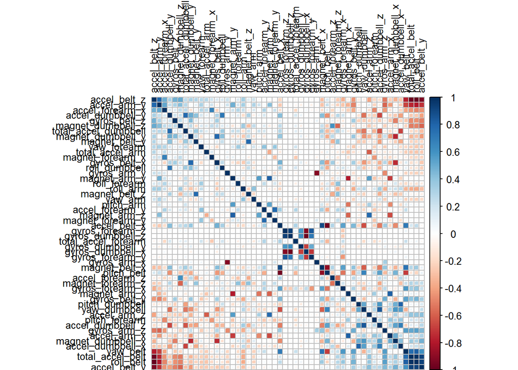

```r
corMatrix <- cor(trainingF[, -length(trainingF)])
corrplot(corMatrix, order = "FPC", method = "square", type = "full", tl.cex = 0.8,  tl.col = rgb(0, 0, 0))
```

In the graph, the dark red and blue colours indicate a highly negative and positive relationship respectively between the variables. However,for this training set it is ok to contain variables which in a high correlation. Training a Model For this part, a new package (parallel)would be used to improve the randomforest performance. And 10 fold cross validation would be used to improve the train model performance.

# Train the model with cross-validation

```r
set.seed(2333)
inTrain <-  createDataPartition(y =trainingF$classe, p = 0.75, list = FALSE)
training <- trainingF[inTrain, ]
crossval <- trainingF[-inTrain, ]
x <- training[,-length(training)]
y <- training[,length(training)]
cluster <- makeCluster(detectCores() - 1)# convention to leave 1 core for OS
fitControl <- trainControl(method = "cv",
                           number = 10,
                           allowParallel = TRUE)
fit <- train(x,y, method="rf",data=trainingF,trControl = fitControl)
stopCluster(cluster)
fit
fit$resample
confusionMatrix.train(fit)
```

```
## Random Forest
##
## 14718 samples
##    52 predictor
##     5 classes: 'A', 'B', 'C', 'D', 'E'
##
## No pre-processing
## Resampling: Cross-Validated (10 fold)
## Summary of sample sizes: 13245, 13248, 13247, 13245, 13246, 13247, ...
## Resampling results across tuning parameters:
##
##   mtry  Accuracy   Kappa
##    2    0.9922543  0.9902010
##   27    0.9921192  0.9900304
##   52    0.9873639  0.9840142
##
## Accuracy was used to select the optimal model using  the largest value.
## The final value used for the model was mtry = 2.
##     Accuracy     Kappa Resample
## 1  0.9911565 0.9888158   Fold02
## 2  0.9898167 0.9871156   Fold01
## 3  0.9938817 0.9922582   Fold03
## 4  0.9891230 0.9862427   Fold06
## 5  0.9904891 0.9879639   Fold05
## 6  0.9952478 0.9939899   Fold04
## 7  0.9932019 0.9913986   Fold07
## 8  0.9938900 0.9922719   Fold10
## 9  0.9911745 0.9888335   Fold09
## 10 0.9945615 0.9931199   Fold08
## Cross-Validated (10 fold) Confusion Matrix
##
## (entries are percentual average cell counts across resamples)
##
##           Reference
## Prediction    A    B    C    D    E
##          A 28.4  0.2  0.0  0.0  0.0
##          B  0.0 19.1  0.1  0.0  0.0
##          C  0.0  0.1 17.3  0.3  0.0
##          D  0.0  0.0  0.0 16.1  0.0
##          E  0.0  0.0  0.0  0.0 18.3
##
##  Accuracy (average) : 0.9923
```

# Prediction of Testing Data

Now the test data would test the model perfomance.In addition ,this data had be cleaned in the begining.

```r
# predict the classes using the testing data set
pred <- predict(fit, testingF)
pred
```

```
##  [1] B A B A A E D B A A B C B A E E A B B B
## Levels: A B C D E
```

# Conclusions

It is possible to accurately predict how well or activity people do based on abundant information.And the Machine Learning shows good perfomance and result when they predict it.